# Youth Behaviour Risk Survey - ethnicity prediction

Lovdip Singh

The class labels are codes as follows:

- `0`=American Indian/Alaskan Native
- `1`=Asian
- `2`=Black/African American
- `3`=Native Hawaiian or other Pacific Islander
- `4`=White
- `5`=Hispanic/Latino
- `6`=multiple race and Hispanic/Latino
- `7`=multiple-race but not Hispanic/Latino

## Goal of study

To build a classifier which predict race from Youth Behaviour Risk Survey data from the US.

### Split data into train and test

```r
load('yrbs.rda')

nrow(x)
```

```
## [1] 15624
```

```r
# remove observations with missing label
x <- as_tibble(x) %>%
  bind_cols(y=r)

x <- apply(x, 2, as.numeric) %>%
  as_tibble() %>%
  drop_na(y)

nrow(x)
```

```
## [1] 15266
```

```r
# one-hot encode categorical variables
all_data <- x[,c(-1,-2, -95)] %>% apply(2, as.factor)
all_dummy <- all_data %>% dummyVars(~., data=.)
all_hot <- as_tibble(data.frame(predict(all_dummy, newdata=all_data))) %>%
  bind_cols(q6=x$q6, q7=x$q7, ., y=x$y) %>% as.matrix()

# train test split 80 20
set.seed(6288842)
samp <- sample(1:nrow(all_hot), 0.8*nrow(x))
train <- all_hot[samp,]
test <- all_hot[-samp,]

train_x <- train[,-ncol(train)]
train_y <- train[,ncol(train)]
test_x <- test[,-ncol(test)]
test_y <- test[,ncol(test)]
```

### Model - cross validation for nrounds

```r
bst <- xgb.cv(data=all_hot[,-ncol(all_hot)],
              label=all_hot[,ncol(all_hot)],
              objective="multi:softprob",
              num_class=8,
              eval_metric='merror',
              early_stopping_rounds=20,
              nrounds=100,
              nfold=10,
              print_every_n=5)
```

[output not shown]

Best `nrounds` parameter appears to be 55.

### Train model

```r
model <- xgboost(data=train_x,
                 label=train_y,
                 objective="multi:softprob",
                 num_class=8,
                 eval_metric='merror',
                 nrounds=55,
                 verbose=0)
```

### Prediction on test data

```r
preds <- predict(model, newdata=test_x, reshape=T)
colnames(preds) <- 0:7
preds <- as.data.frame(preds)
# highest probability label
preds$prediction <- apply(preds, 1, function(x) colnames(preds)[which.max(x)])
# confusion matrix
confusionMatrix(factor(preds$prediction, levels=0:7), factor(test_y))
```

```
## Confusion Matrix and Statistics
##
##           Reference
## Prediction    0    1    2    3    4    5    6    7
##          0    0    0    0    0    0    0    0    0
##          1    0   28    5    0    5    6    9    3
##          2    3    8  147    2   46   43   51   23
##          3    0    0    0    0    0    0    0    0
##          4   19   50   78    6 1235  159  232   81
##          5    1   19   40    4   55  177  115    8
##          6    3   25   56    1   60   98  129   19
##          7    0    1    1    0    1    1    1    0
##
## Overall Statistics
##
##                Accuracy : 0.5619
##                  95% CI : (0.5441, 0.5796)
##     No Information Rate : 0.4591
##     P-Value [Acc > NIR] : < 2.2e-16
##
##                   Kappa : 0.3402
##
##  Mcnemar's Test P-Value : NA
##
## Statistics by Class:
##
##                      Class: 0 Class: 1 Class: 2 Class: 3 Class: 4 Class: 5
## Sensitivity          0.000000 0.213740  0.44954 0.000000   0.8809  0.36570
## Specificity          1.000000 0.990421  0.93546 1.000000   0.6217  0.90584
## Pos Pred Value            NaN 0.500000  0.45511      NaN   0.6640  0.42243
## Neg Pred Value       0.991487 0.965644  0.93409 0.995743   0.8601  0.88349
## Prevalence           0.008513 0.042895  0.10707 0.004257   0.4591  0.15848
## Detection Rate       0.000000 0.009168  0.04813 0.000000   0.4044  0.05796
## Detection Prevalence 0.000000 0.018337  0.10576 0.000000   0.6090  0.13720
## Balanced Accuracy    0.500000 0.602081  0.69250 0.500000   0.7513  0.63577
##                      Class: 6 Class: 7
## Sensitivity           0.24022 0.000000
## Specificity           0.89591 0.998288
## Pos Pred Value        0.32992 0.000000
## Neg Pred Value        0.84679 0.956051
## Prevalence            0.17583 0.043877
## Detection Rate        0.04224 0.000000
## Detection Prevalence  0.12803 0.001637
## Balanced Accuracy     0.56807 0.499144
```

The default parameters for XGBoost were used. Overall accuracy is not great ~56% but this is not surprising as very few questions are indicative of race, the ‘splits’ are not able to completely separate classes and the data are self reported. Missing values were also left for XGBoost to impute.

## Variable important in prediction

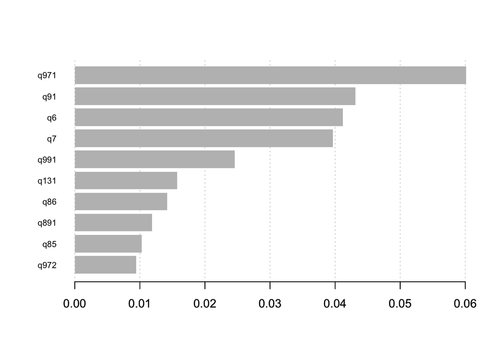

```r
importance <- xgb.importance(feature_names=colnames(train_x), model=model)
xgb.plot.importance(importance_matrix=importance, top_n=10, left_margin=5)
```

The 10 most important variables with respect to XGBoost gain metric:

1. `q97` During the past 12 months, how many times have you had a sunburn?
   - Response 1: 0 times
2. `q9` How often do you wear a seat belt when riding in a car driven by someone else?
   - Response 1: Never
3. `q6` How tall are you without your shoes on?
4. `q7` How much do you weigh without your shoes on?
5. `q99` How well do you speak English?
   - Response 1: Very well
6. `q13` During the past 30 days, on how many days did you carry a weapon such as a gun, knife, or club?
   - Response 1: 0 days
7. `q8` When you rode a bicycle during the past 12 months, how often did you wear a helmet?
   - Response 6: Always wore a helmet
8. `q89` During the past 12 months, how would you describe your grades in school?
   - Response 1: Mostly A’s
9. `q8` When you rode a bicycle during the past 12 months, how often did you wear a helmet?
   - Response 5: Most of the time wore a helmet
10. `q97` During the past 12 months, how many times have you had a sunburn?
    - Response 2: 1 time

## Important variables for a particular race

We can use SHAP values to determine how a variable relates to the labels. The mean of the absolute value of the SHAP value can show how positively or negatively the variable relates to the class labels.

### Top 10 most important features - SHAP values

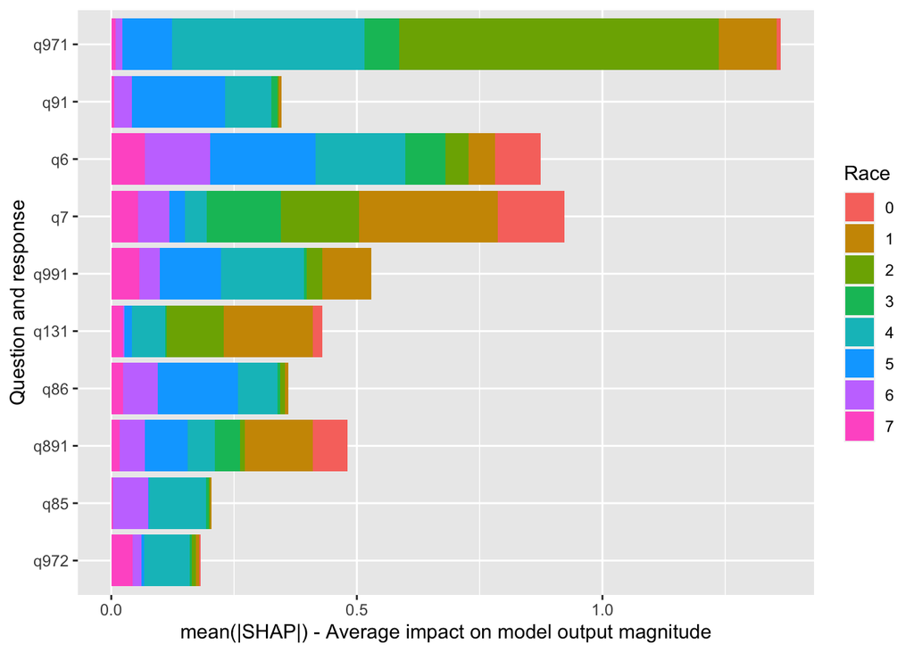

```r
shap_values <- shap.values(model, train_x)

# function to get SHAP values for variables and classes
get_shap <- function(x) {
  vars <- paste0(x, c('', '.1', '.2', '.3', '.4', '.5', '.6', '.7'))
  values <- shap_values[[2]][vars]
  tble <- tibble(r=0:7, x=values)
  colnames(tble) <- c('r', x)
  tble
}
# SHAP values for top 10 important features
top_10_shap <- lapply(importance$Feature[1:10], get_shap) %>%
  reduce(inner_join, by='r') %>%
  pivot_longer(!r)

top_10_shap$r <- factor(top_10_shap$r)
top_10_shap$name <- factor(top_10_shap$name, levels=rev(importance$Feature[1:10]))

ggplot(top_10_shap, aes(name, value)) +
  geom_bar(aes(fill=r), stat='identity') +
  coord_flip() +
  labs(y='mean(|SHAP|) - Average impact on model output magnitude', x='Question and response', fill='Race')
```

### Greatest SHAP for each class - highest impact on model

For each label, we can see variables such that the label has the highest mean absolute SHAP value, then we can see which of these variables, the given label has the highest SHAP. We can then determine that this variable can be interpreted as a distinctive feature for the class label.

```r
all_shap <- lapply(colnames(all_hot[,-ncol(all_hot)]), get_shap) %>%
  reduce(inner_join, by='r') %>%
  pivot_longer(!r)

all_shap$r <- factor(all_shap$r)

# highest SHAP prop for each class
highest_shap <- all_shap %>%
  group_by(name) %>%
  summarise(value=max(value))
```

```r
highest_shap <- highest_shap %>%
  inner_join(all_shap, by=c('name', 'value')) %>%
  arrange(desc(value))

# function to get questions where class is the highest prop
get_highest_shap <- function(class){
  t <- highest_shap %>% filter(r==class)
  t$name[1]
}

# plot questions where each class is the highest SHAP value
highest_shap_questions <- sapply(as.character(0:7), get_highest_shap)
highest_shap_tble <- lapply(highest_shap_questions, get_shap) %>%
  reduce(inner_join, by='r') %>%
  pivot_longer(!r)

highest_shap_tble$r <- factor(highest_shap_tble$r)
highest_shap_tble$name <- factor(highest_shap_tble$name,
                                 levels=rev(c('q761', 'q7', 'q971',
                                              'q951', 'q972', 'q6', 'q101','q992')))
```

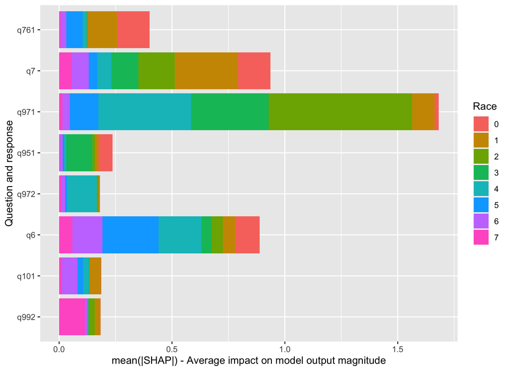

```r
# (was getting error when knitting so saved plot and attached png instead)
ggplot(highest_shap_tble, aes(name, value)) +
  geom_bar(aes(fill=r), stat='identity') +
  coord_flip() +
  labs(y='mean(|SHAP|) - Average impact on model output magnitude', x='Question and response', fill='Race')
```

The most distinctive features for each class are ordered vertically in the graph for race codes 0 to 7.

### Summarising some distinctive features for `1`=Asian, `2`=Black/African American, `4`=White, `5`=Hispanic/Latino

`q6` and `q7` ask about the persons height and weight respectively.

```r
q6 <- as_tibble(train_x) %>%
  mutate(Race=train_y) %>%
  select(q6, Race) %>%
  group_by(Race) %>%
  summarise(`Average height (m)`=mean(q6, na.rm=T))
q7 <- as_tibble(train_x) %>%
  mutate(Race=train_y) %>%
  select(q7, Race) %>%
  group_by(Race) %>%
  summarise(`Average weight (kg)`=mean(q7, na.rm=T))
knitr::kable(q6, align='l') %>%
  kable_styling(position='left', full_width = F)
```

| Race | Average height (m) |
| --- | --- |
| 0 | 1.698730 |
| 1 | 1.652208 |
| 2 | 1.697237 |
| 3 | 1.697397 |
| 4 | 1.703960 |
| 5 | 1.658855 |
| 6 | 1.669703 |
| 7 | 1.692951 |

```r
knitr::kable(q7, align='l') %>%
  kable_styling(position='left', full_width = F)
```

| Race | Average weight (kg) |
| --- | --- |
| 0 | 69.07714 |
| 1 | 60.88355 |
| 2 | 69.30450 |
| 3 | 71.02890 |
| 4 | 68.09407 |
| 5 | 67.18410 |
| 6 | 67.70002 |
| 7 | 68.39991 |

```r
q971 <- as_tibble(train_x) %>%
  mutate(Race=train_y) %>%
  select(q971, Race) %>%
  group_by(Race) %>%
  summarise(`Sunburned 0 times`=mean(q971, na.rm=T))
q972 <- as_tibble(train_x) %>%
  select(q972, q973, q974, q975, q976) %>%
  rowwise() %>%
  summarise(Total=sum(q972, q973, q974, q975, q976, na.rm=T)) %>%
  mutate(Race=train_y) %>%
  group_by(Race) %>%
  summarise(`Sunburned 1 or more times`=mean(Total))
knitr::kable(q971, align='l') %>%
  kable_styling(position='left', full_width = F)
```

| Race | Sunburned 0 times |
| --- | --- |
| 0 | 0.6168224 |
| 1 | 0.7147335 |
| 2 | 0.8659148 |
| 3 | 0.6851852 |
| 4 | 0.2802018 |
| 5 | 0.6479730 |
| 6 | 0.5548743 |
| 7 | 0.5274463 |

```r
knitr::kable(q972, align='l') %>%
  kable_styling(position='left', full_width = F)
```

| Race | Sunburned 1 or more times |
| --- | --- |
| 0 | 0.2992701 |
| 1 | 0.1834677 |
| 2 | 0.0798507 |
| 3 | 0.1954023 |
| 4 | 0.5239581 |
| 5 | 0.2769803 |
| 6 | 0.3271744 |
| 7 | 0.3272727 |

Of the Black/African American people that answered `q97`, 87% said that the have be sunburned 0 times in the past 12 months. Of the White people that answered `q97`, 52% said they were sunburned 1 or times during the last 12 months.

## Conclusions - ethical considerations

Task 3 would be ethically problematic if intended to be published. We are analyzing a model based on high-school student responses to a survey, they may not have consented for the results of the survey to be analysed in such a way that classifies their race. Secondly publishing these results can be seen as discriminatory as we are classifying race solely on self reported and somewhat sensitive questions for example alcohol consumption, this is especially problematic sense we are generalizing these results to a some-what vulnerable demographic - high school students. This can also lead to a people being judgmental for particular races, which can lead to institutionalised racism as people may feel certain races are not worthy of certain roles in society. The model also doesn’t perform greatly which will be problematic if used to label individuals.